# MNIST

## Reconhecimento de dígitos com MLP

Esse documento traz uma implementação de uma MLP simples usando a biblioteca pytorch.

```python
import torch
import torch.nn as nn
from torchvision import datasets
from torch.utils.data import dataloader
from torchvision.transforms import Compose
from torchvision.transforms import ToTensor
from torchvision.transforms import PILToTensor
from matplotlib import pyplot as plt
from sklearn.metrics import confusion_matrix, ConfusionMatrixDisplay
import numpy as np
```

```python
BATCH_SIZE = 128
EPOCHS = 5
device = torch.device('cuda' if torch.cuda.is_available() else 'cpu')

data_train = datasets.MNIST(root='DataSets',
                            train=True,
                            download=True,
                            transform=ToTensor()) # Normaliza os dados [0,255] -> [0,1]
data_test = datasets.MNIST(root='DataSets',
                            train=False,
                            download=True,
                            transform=ToTensor())


train_loader = dataloader.DataLoader(dataset=data_train, batch_size=BATCH_SIZE, shuffle=True)
test_loader = dataloader.DataLoader(dataset=data_test, batch_size=BATCH_SIZE, shuffle=False)
```

```python
class MLP(nn.Module):
    def __init__(self,input_size,hidden_size, output_size):
        super(MLP,self).__init__()
        self.fc1 = nn.Linear(input_size,hidden_size)
        self.tanh1 = nn.Tanh()
        self.fc2 = nn.Linear(hidden_size,hidden_size)
        self.tanh2 = nn.Tanh()
        self.fc3 = nn.Linear(hidden_size,output_size)

    def forward(self, x):

        x = x.view(-1, 28*28)
        out = self.fc1(x)
        out = self.tanh1(out)
        out = self.fc2(out)
        out = self.tanh2(out)
        out = self.fc3(out)
        return out
```

```python
mod = MLP(28*28, 256, 10)

loss_func = nn.CrossEntropyLoss()
opt = torch.optim.Adam(params=mod.parameters(), lr=0.001)

print("Arquitetura do Modelo:")
print(mod)
```

```
Arquitetura do Modelo:
MLP(
  (fc1): Linear(in_features=784, out_features=256, bias=True)
  (tanh1): Tanh()
  (fc2): Linear(in_features=256, out_features=256, bias=True)
  (tanh2): Tanh()
  (fc3): Linear(in_features=256, out_features=10, bias=True)
)
```

```python
history_norm = {'loss': [], 'accuracy': []}
total_step = len(train_loader)

print("\n--- INICIANDO TREINAMENTO COM DADOS NORMALIZADOS ---")
mod.to(device)
mod.train()
for epoch in range(EPOCHS):
    total_loss = 0
    correct = 0
    total = 0
    for i, (images, labels) in enumerate(train_loader):
        # Forward pass
        images = images.to(device)
        labels = labels.to(device)
        outputs = mod(images)
        loss = loss_func(outputs, labels)

        # Backward and optimize
        opt.zero_grad()
        loss.backward()
        opt.step()

        # Monitoramento
        total_loss += loss.item()
        _, predicted = torch.max(outputs.data, 1)
        total += labels.size(0)
        correct += (predicted == labels).sum().item()

    epoch_loss = total_loss / total_step
    epoch_acc = 100 * correct / total
    history_norm['loss'].append(epoch_loss)
    history_norm['accuracy'].append(epoch_acc)

    print(f'Época [{epoch+1}/{EPOCHS}], Perda: {epoch_loss:.4f}, Acurácia: {epoch_acc:.2f}%')

print("--- TREINAMENTO CONCLUÍDO ---")
```

```
--- INICIANDO TREINAMENTO COM DADOS NORMALIZADOS ---
Época [1/5], Perda: 0.3257, Acurácia: 90.58%
Época [2/5], Perda: 0.1492, Acurácia: 95.52%
Época [3/5], Perda: 0.1038, Acurácia: 96.81%
Época [4/5], Perda: 0.0746, Acurácia: 97.73%
Época [5/5], Perda: 0.0571, Acurácia: 98.21%
--- TREINAMENTO CONCLUÍDO ---
```

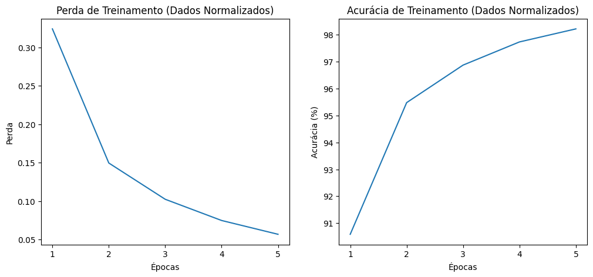

```python
fig, (ax1, ax2) = plt.subplots(1, 2, figsize=(12, 5))
# Gráfico de Perda
ax1.set_xticks([0,1,2,3,4],[1,2,3,4,5])
ax1.plot(history_norm['loss'])
ax1.set_title('Perda de Treinamento (Dados Normalizados)')
ax1.set_xlabel('Épocas')
ax1.set_ylabel('Perda')


# Gráfico de Acurácia
ax2.set_xticks([0,1,2,3,4],[1,2,3,4,5])
ax2.plot(history_norm['accuracy'])
ax2.set_title('Acurácia de Treinamento (Dados Normalizados)')
ax2.set_xlabel('Épocas')
ax2.set_ylabel('Acurácia (%)')
plt.show()
```

```python
mod.eval()
all_preds = []
all_labels = []
with torch.no_grad():
    correct = 0
    total = 0
    for images, labels in test_loader:

        images = images.to(device)
        labels = labels.to(device)

        outputs = mod(images)
        _, predicted = torch.max(outputs.data, 1)
        total += labels.size(0)
        correct += (predicted == labels).sum().item()


        all_preds.extend(predicted.cpu().numpy())
        all_labels.extend(labels.cpu().numpy())

accuracy_test = 100 * correct / total
print(f'\nAcurácia do modelo no conjunto de teste: {accuracy_test:.2f} %')
```

```
Acurácia do modelo no conjunto de teste: 97.55 %
```

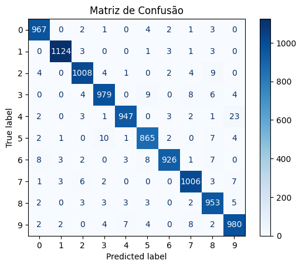

```python
cm = confusion_matrix(all_labels, all_preds)
disp = ConfusionMatrixDisplay(confusion_matrix=cm, display_labels=np.arange(10))
disp.plot(cmap=plt.cm.Blues)
plt.title('Matriz de Confusão')
plt.show()
```

## Análise de Desempenho e Generalização do Modelo

A análise do modelo indica um processo de aprendizado eficaz que resultou em uma excelente capacidade de generalização, conforme demonstrado pelo seu forte desempenho no conjunto de teste.

Durante o treinamento, observou-se uma melhoria contínua e estável das métricas no conjunto de treino, indicando que o modelo foi capaz de aprender consistentemente os padrões dos dados fornecidos. O principal indicativo de que este aprendizado não levou a um overfitting prejudicial vem da alta acurácia alcançada no conjunto de teste ao final do processo.

Se o modelo tivesse superajustado significativamente, ele teria essencialmente "decorado" os exemplos de treino, resultando em um baixo desempenho ao ser exposto a dados novos e nunca vistos. O fato de ter alcançado uma alta acurácia no teste contradiz diretamente essa possibilidade.

Embora a ausência de um conjunto de validação durante o treinamento impeça a análise da evolução da generalização a cada época, o resultado final robusto sugere que o número total de épocas foi apropriado, levando a um modelo que não apenas aprendeu bem, mas que também soube generalizar esse conhecimento de forma eficaz.

## Treinamento com dados não normalizados

```python
#Carregamento do dado sem processamento
transform_nonorm = Compose([
    PILToTensor(),
    lambda x: x.float()
])

data_train = datasets.MNIST(root='DataSets',
                            train=True,
                            download=True,
                            transform= transform_nonorm)
data_test = datasets.MNIST(root='DataSets',
                            train=False,
                            download=True,
                            transform= transform_nonorm)
train_loader = dataloader.DataLoader(dataset=data_train, batch_size=BATCH_SIZE, shuffle=True)
test_loader = dataloader.DataLoader(dataset=data_test, batch_size=BATCH_SIZE, shuffle=False)
```

```python
mod = MLP(28*28, 256, 10)

loss_func = nn.CrossEntropyLoss()
opt = torch.optim.Adam(params=mod.parameters(), lr=0.001)

print("Arquitetura do Modelo:")
print(mod)
```

```
Arquitetura do Modelo:
MLP(
  (fc1): Linear(in_features=784, out_features=256, bias=True)
  (tanh1): Tanh()
  (fc2): Linear(in_features=256, out_features=256, bias=True)
  (tanh2): Tanh()
  (fc3): Linear(in_features=256, out_features=10, bias=True)
)
```

```python
history_nonorm = {'loss': [], 'accuracy': []}
total_step = len(train_loader)

print("\n--- INICIANDO TREINAMENTO COM DADOS NAO NORMALIZADOS ---")
mod.to(device)
mod.train()
for epoch in range(EPOCHS):
    total_loss = 0
    correct = 0
    total = 0
    for i, (images, labels) in enumerate(train_loader):
        # Forward pass
        images = images.to(device)
        labels = labels.to(device)
        outputs = mod(images)
        loss = loss_func(outputs, labels)

        # Backward and optimize
        opt.zero_grad()
        loss.backward()
        opt.step()

        # Monitoramento
        total_loss += loss.item()
        _, predicted = torch.max(outputs.data, 1)
        total += labels.size(0)
        correct += (predicted == labels).sum().item()

    epoch_loss = total_loss / total_step
    epoch_acc = 100 * correct / total
    history_nonorm['loss'].append(epoch_loss)
    history_nonorm['accuracy'].append(epoch_acc)

    print(f'Época [{epoch+1}/{EPOCHS}], Perda: {epoch_loss:.4f}, Acurácia: {epoch_acc:.2f}%')

print("--- TREINAMENTO CONCLUÍDO ---")
```

[output not shown]

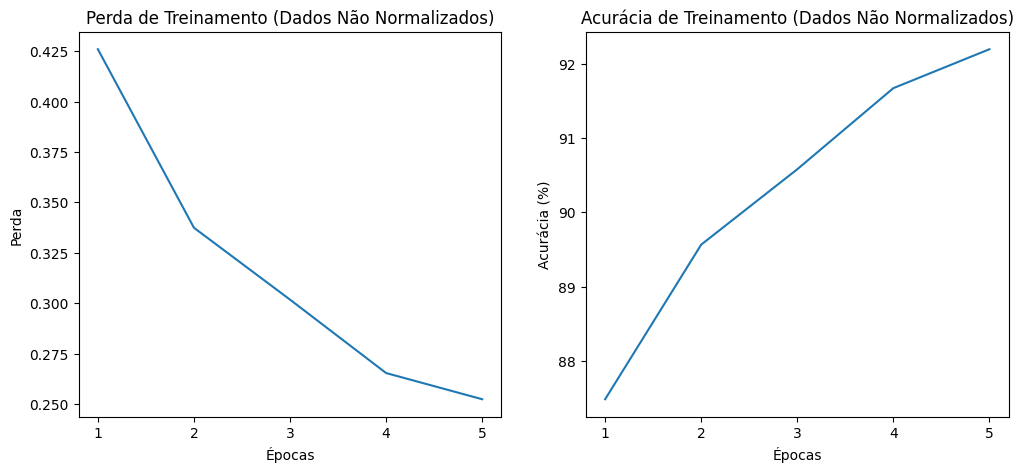

```python
fig, (ax1, ax2) = plt.subplots(1, 2, figsize=(12, 5))
# Gráfico de Perda
ax1.set_xticks([0,1,2,3,4],[1,2,3,4,5])
ax1.plot(history_nonorm['loss'])
ax1.set_title('Perda de Treinamento (Dados Não Normalizados)')
ax1.set_xlabel('Épocas')
ax1.set_ylabel('Perda')

# Gráfico de Acurácia
ax2.set_xticks([0,1,2,3,4],[1,2,3,4,5])
ax2.plot(history_nonorm['accuracy'])
ax2.set_title('Acurácia de Treinamento (Dados Não Normalizados)')
ax2.set_xlabel('Épocas')
ax2.set_ylabel('Acurácia (%)')

plt.show()
```

```python
mod.eval()
all_preds = []
all_labels = []
with torch.no_grad():
    correct = 0
    total = 0
    for images, labels in test_loader:
        # --- 3. MOVER OS DADOS DE TESTE PARA A GPU --- ### GPU ###
        images = images.to(device)
        labels = labels.to(device)

        outputs = mod(images)
        _, predicted = torch.max(outputs.data, 1)
        total += labels.size(0)
        correct += (predicted == labels).sum().item()

        # Para a matriz de confusão, precisamos trazer os dados de volta para a CPU
        all_preds.extend(predicted.cpu().numpy())
        all_labels.extend(labels.cpu().numpy())

accuracy_test_nonorm = 100 * correct / total
print(f'\nAcurácia do modelo no conjunto de teste: {accuracy_test_nonorm:.2f} %')
```

```
Acurácia do modelo no conjunto de teste: 90.92 %
```

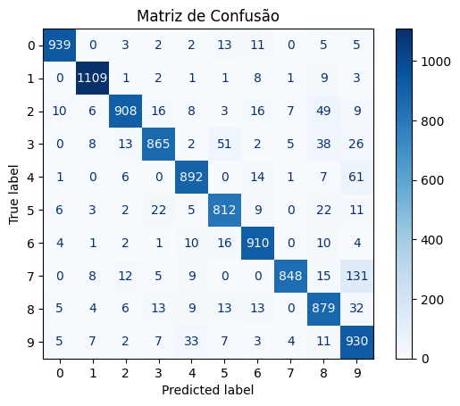

```python
#Matriz de confusão

cm = confusion_matrix(all_labels, all_preds)
disp = ConfusionMatrixDisplay(confusion_matrix=cm, display_labels=np.arange(10))
disp.plot(cmap=plt.cm.Blues)
plt.title('Matriz de Confusão')
plt.show()
```

## Comparando modelo com ajuste vs modelo sem ajuste

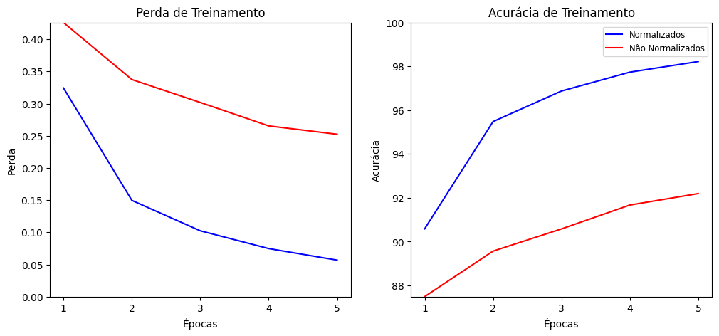

```python
fig, (ax1, ax2) = plt.subplots(1, 2, figsize=(12, 5))
# Gráfico de Perda
ax1.set_xticks([0,1,2,3,4],[1,2,3,4,5])
ax1.plot(history_nonorm['loss'],color = "red")
ax1.plot(history_norm['loss'],color = "blue")
ax1.set_title('Perda de Treinamento')
ax1.set_xlabel('Épocas')
ax1.set_ylabel('Perda')

ax1.set_ylim(0,max(history_nonorm["loss"]+history_norm["loss"]))

# Gráfico de Acurácia
ax2.set_xticks([0,1,2,3,4],[1,2,3,4,5])
ax2.plot(history_norm['accuracy'],color = 'blue')
ax2.plot(history_nonorm['accuracy'],color = 'red')
ax2.set_title('Acurácia de Treinamento')
ax2.set_xlabel('Épocas')
ax2.set_ylabel('Acurácia')
ax2.set_ylim(min(history_nonorm["accuracy"]+history_norm["accuracy"]),100)

ax2.legend(["Normalizados","Não Normalizados"],fontsize = 'small')


plt.show()
```

# Relatório de Análise e Comparação de Modelos MLP

## 1. Introdução

Este relatório apresenta uma análise comparativa do desempenho de dois modelos de Perceptron de Múltiplas Camadas (MLP) para uma tarefa de classificação. O objetivo principal é avaliar o impacto da normalização dos dados de entrada no processo de treinamento e na performance final do modelo. Ambos os modelos foram treinados com a mesma arquitetura e os mesmos hiperparâmetros, variando apenas o pré-processamento dos dados.

## 2. Arquitetura do Modelo

A mesma arquitetura de rede neural foi utilizada para ambos os experimentos. A estrutura do MLP é composta por:

- **Camada de Entrada:** Uma camada linear que transforma o vetor de entrada em um espaço de features de dimensão intermediária.
- **Primeira Camada Oculta:** Uma camada com neurônios e função de ativação Tangente Hiperbólica (Tanh).
- **Segunda Camada Oculta:** Uma segunda camada com a mesma estrutura da anterior.
- **Camada de Saída:** Uma camada linear final que mapeia o espaço de features para as classes de saída.

**Resumo da Arquitetura:** `Input -> Linear -> Tanh -> Linear -> Tanh -> Linear -> Output`

## 3. Hiperparâmetros de Treinamento

Os seguintes hiperparâmetros foram mantidos constantes durante o treinamento de ambos os modelos para garantir uma comparação justa:

- **Otimizador:** Adam
- **Taxa de Aprendizado (Learning Rate):** 0.001
- **Tamanho do Lote (Batch Size):** 128
- **Número de Épocas (Epochs):** 5

## 4. Análise dos Resultados

### 4.1. Modelo 1: Treinado com Dados Normalizados

Neste cenário, os dados de entrada foram pré-processados e escalonados para um intervalo menor.

- **Desempenho no Treinamento:** O modelo demonstrou um aprendizado eficiente, atingindo um alto desempenho ao final das épocas de treinamento.
- **Acurácia Final no Conjunto de Teste:** Alta

### Tabela 1: Matriz de Confusão (Dados Normalizados)

*Esta tabela mostra o desempenho do modelo treinado com dados normalizados. As linhas representam a classe verdadeira e as colunas representam a classe predita pelo modelo.*

| Classe Verdadeira / Predita | **0** | **1** | **2** | **3** | **4** | **5** | **6** | **7** | **8** | **9** |
| --- | --- | --- | --- | --- | --- | --- | --- | --- | --- | --- |
| **0** | 967 | 0 | 2 | 1 | 0 | 4 | 2 | 1 | 3 | 0 |
| **1** | 0 | 1124 | 3 | 0 | 0 | 1 | 3 | 1 | 3 | 0 |
| **2** | 4 | 0 | 1008 | 4 | 1 | 0 | 2 | 4 | 9 | 0 |
| **3** | 0 | 0 | 4 | 979 | 0 | 9 | 0 | 8 | 6 | 4 |
| **4** | 2 | 0 | 3 | 1 | 947 | 0 | 3 | 2 | 1 | 23 |
| **5** | 2 | 1 | 0 | 10 | 1 | 865 | 2 | 0 | 7 | 4 |
| **6** | 8 | 3 | 2 | 0 | 3 | 8 | 926 | 1 | 7 | 0 |
| **7** | 1 | 3 | 6 | 2 | 0 | 0 | 0 | 1006 | 3 | 7 |
| **8** | 2 | 0 | 3 | 3 | 3 | 3 | 0 | 2 | 953 | 5 |
| **9** | 2 | 2 | 0 | 4 | 7 | 4 | 0 | 8 | 2 | 980 |

- **Análise dos Resultados:** A matriz de confusão exibe uma diagonal principal dominante, indicando que o modelo possui alta capacidade de acertar a classificação para a maioria das classes. Os valores fora da diagonal principal, que representam os erros, são notavelmente baixos, sugerindo que o modelo generaliza bem e raramente confunde as classes. O desempenho geral pode ser considerado robusto.

### 4.2. Modelo 2: Treinado com Dados Não Normalizados

Aqui, os dados brutos, sem escalonamento, foram usados para o treinamento.

- **Desempenho no Treinamento:** O aprendizado foi visivelmente menos eficaz, resultando em um desempenho de treinamento inferior em comparação ao modelo normalizado.
- **Acurácia Final no Conjunto de Teste:** Inferior

### Tabela 2: Matriz de Confusão (Dados Não Normalizados)

*Esta tabela mostra o desempenho do modelo treinado com dados brutos (não normalizados). Note a maior quantidade de erros (valores fora da diagonal principal) em comparação com a primeira tabela.*

| Classe Verdadeira / Predita | **0** | **1** | **2** | **3** | **4** | **5** | **6** | **7** | **8** | **9** |
| --- | --- | --- | --- | --- | --- | --- | --- | --- | --- | --- |
| **0** | 939 | 0 | 3 | 2 | 2 | 13 | 11 | 0 | 5 | 5 |
| **1** | 0 | 1109 | 1 | 2 | 1 | 1 | 8 | 1 | 9 | 3 |
| **2** | 10 | 6 | 908 | 16 | 8 | 3 | 16 | 7 | 49 | 9 |
| **3** | 0 | 8 | 13 | 865 | 2 | 51 | 2 | 5 | 38 | 26 |
| **4** | 1 | 0 | 6 | 0 | 892 | 0 | 14 | 1 | 7 | 61 |
| **5** | 6 | 3 | 2 | 22 | 5 | 812 | 9 | 0 | 22 | 11 |
| **6** | 4 | 1 | 2 | 1 | 10 | 16 | 910 | 0 | 10 | 4 |
| **7** | 0 | 8 | 12 | 5 | 9 | 0 | 0 | 848 | 15 | 131 |
| **8** | 5 | 4 | 6 | 13 | 9 | 13 | 13 | 0 | 879 | 32 |
| **9** | 5 | 7 | 2 | 7 | 33 | 7 | 3 | 4 | 11 | 930 |

- **Análise dos Resultados:** A matriz de confusão deste modelo revela uma performance significativamente inferior. Embora a diagonal principal ainda concentre a maioria das predições, a quantidade de classificações incorretas (valores fora da diagonal) é substancialmente maior. Isso indica que o modelo teve mais dificuldade para aprender as características que distinguem as classes, resultando em uma menor capacidade de generalização.

## 5. Comparação e a Importância da Normalização

A comparação direta entre os dois modelos revela a superioridade inequívoca da abordagem com dados normalizados. O primeiro modelo demonstrou ter maior capacidade de aprendizado e, mais importante, generalizou de forma muito mais eficaz para os dados de teste. O segundo modelo, por sua vez, mostrou-se menos capaz de aprender e generalizar, evidenciando a importância do pré-processamento.

**Por que a normalização é tão importante?**

- **Convergência Mais Rápida:** Otimizadores funcionam melhor quando os dados de entrada estão em uma escala semelhante, permitindo que o modelo aprenda de forma mais rápida e estável.
- **Estabilidade Numérica:** Manter os valores de entrada em um intervalo pequeno ajuda a manter as ativações e gradientes sob controle, garantindo um processo de treinamento mais estável e evitando problemas numéricos.
- **Eficiência das Funções de Ativação:** A normalização ajuda a manter as entradas em uma região onde as funções de ativação são mais sensíveis, evitando a saturação dos neurônios e permitindo que o aprendizado flua adequadamente por toda a rede.

## 6. Conclusão

Os resultados demonstram que a normalização dos dados é um passo de pré-processamento fundamental. O modelo treinado com dados normalizados apresentou uma capacidade de generalização significativamente superior, resultando em um modelo final mais robusto e confiável.